# Aviation Incident Analysis for Safety Optimization

## Project Overview

This project focuses on assessing aviation incident and accident data to identify patterns, trends, and risk factors that contribute to aircraft safety events. By checking into structured records which includes; year, location, aircraft type and model, engine type,aircraft damage, amateur built, flight purpose, weather conditions and injury severity. The analysis aims to establish insights that can enhance aviation safety. The findings are intended to support improvements in policy, pilot training, aircraft design, and operational procedures. The key stakeholders include aviation authorities (e.g., FAA, KCAA), aircraft manufacturers, airlines, flight schools, safety analysts, data scientists, and regulators. The project operates within the aviation and aerospace industry, specifically in the domain of safety analytics and accident investigation, serving departments such as safety oversight, risk management, and data science.

## Business Problem

Even with modern improvements in aviation technology, safety incidents still continue to occur across different types of aircraft and in various parts of the world. Stakeholders don’t yet have a clear, data-based understanding of which factors like aircraft model, engine type, or location contribute to serious accidents. This gap in insight risks misdirecting safety interventions and limiting their effectiveness. This project aims to identify trends in incident severity over time and geography, find out which aircraft models and engine types are most often involved, assess the effect of weather changes on aviation incidences, explore how different aircraft features relate to accident types and determine the number of aviation incidences originating from amateur built aircrafts. The goal is to offer useful insights that can improve safety rules and pilot training. Success will be measured by the clear identification of high-risk aircraft models or regions, creation of easy-to-understand visuals that show trends, get safety teams to use the findings, and a potential long-term reduction in incident rates.

# Data Understanding

```python
# initial Preview
import pandas as pd

df = pd.read_csv("c:/Users/User/dsc-phase-1-project-v3/data/aviation_data.csv")
```

```python
# Set low_memory=False - to tell pandas to read the file
df = pd.read_csv("c:/Users/User/dsc-phase-1-project-v3/data/aviation_data.csv", low_memory=False)
```

```python
# treating columns with different data types as strings to avoid errors and ensures consistent data types for analysis and visualization
df = pd.read_csv("c:/Users/User/dsc-phase-1-project-v3/data/aviation_data.csv", dtype={
    'column_name_6': str,
    'column_name_7': str,
    'column_name_28': str
},
low_memory=False
)
```

```python
# column index of the dataframe
print(df.columns.tolist())
```

```
['Event.Id', 'Investigation.Type', 'Accident.Number', 'Event.Date', 'Location', 'Country', 'Latitude', 'Longitude', 'Airport.Code', 'Airport.Name', 'Injury.Severity', 'Aircraft.damage', 'Aircraft.Category', 'Registration.Number', 'Make', 'Model', 'Amateur.Built', 'Number.of.Engines', 'Engine.Type', …
```

```python
# summary of the columns
df.info()
```

```
<class 'pandas.core.frame.DataFrame'>
RangeIndex: 90348 entries, 0 to 90347
Data columns (total 31 columns):
 #   Column                  Non-Null Count  Dtype
---  ------                  --------------  -----
 0   Event.Id                88889 non-null  object
 1   Investigation.Type      90348 non-null  object
 2   Accident.Number         88889 non-null  object
 3   Event.Date              88889 non-null  object
 4   Location                88837 non-null  object
 5   Country                 88663 non-null  object
 6   Latitude                34382 non-null  object
 7   Longitude               34373 non-null  object
 8   Airport.Code            50132 non-null  object
 9   Airport.Name            52704 non-null  object
```

[output cut: 23 more lines]

```python
df.head()
```

|  | Event.Id | Investigation.Type | Accident.Number | Event.Date | Location | Country | Latitude | Longitude | Airport.Code | Airport.Name | ... | Purpose.of.flight | Air.carrier | Total.Fatal.Injuries | Total.Serious.Injuries | Total.Minor.Injuries | Total.Uninjured | Weather.Condition | Broad.phase.of.flight | Report.Status | Publication.Date |
| --- | --- | --- | --- | --- | --- | --- | --- | --- | --- | --- | --- | --- | --- | --- | --- | --- | --- | --- | --- | --- | --- |
| 0 | 20001218X45444 | Accident | SEA87LA080 | 1948-10-24 | MOOSE CREEK, ID | United States | NaN | NaN | NaN | NaN | ... | Personal | NaN | 2.0 | 0.0 | 0.0 | 0.0 | UNK | Cruise | Probable Cause | NaN |
| 1 | 20001218X45447 | Accident | LAX94LA336 | 1962-07-19 | BRIDGEPORT, CA | United States | NaN | NaN | NaN | NaN | ... | Personal | NaN | 4.0 | 0.0 | 0.0 | 0.0 | UNK | Unknown | Probable Cause | 19-09-1996 |
| 2 | 20061025X01555 | Accident | NYC07LA005 | 1974-08-30 | Saltville, VA | United States | 36.922223 | -81.878056 | NaN | NaN | ... | Personal | NaN | 3.0 | NaN | NaN | NaN | IMC | Cruise | Probable Cause | 26-02-2007 |
| 3 | 20001218X45448 | Accident | LAX96LA321 | 1977-06-19 | EUREKA, CA | United States | NaN | NaN | NaN | NaN | ... | Personal | NaN | 2.0 | 0.0 | 0.0 | 0.0 | IMC | Cruise | Probable Cause | 12-09-2000 |
| 4 | 20041105X01764 | Accident | CHI79FA064 | 1979-08-02 | Canton, OH | United States | NaN | NaN | NaN | NaN | ... | Personal | NaN | 1.0 | 2.0 | NaN | 0.0 | VMC | Approach | Probable Cause | 16-04-1980 |

5 rows × 31 columns

```python
# checking duplicated data
df.duplicated().sum()
```

```
1390
```

# Data Cleaning/Preparation

The data will be cleaned and standardized by handling missing values, correcting inconsistent text formats, and ensuring uniform data types across key columns. This is aimed at improving data quality, reduce ambiguity and enable reliable analysis of incident patterns and severity.

## Cleaning Steps

- Standardizing column names
- Handling Duplicates
- Handling missing values

# Standardizing Column Names

```python
## Standardizing columns
aviation = pd.read_csv("aviation_data.csv", low_memory=False)
aviation['Weather.Condition'] = aviation['Weather.Condition'].str.title().str.strip()
aviation['Injury.Severity'] = aviation['Injury.Severity'].str.title().str.strip()
```

```python
## Clean column names
df.columns = df.columns.str.strip().str.lower().str.replace(' ', '_')
```

```python
## clean location column
df['country'] = df['country'].str.strip().str.upper()
df['location'] = df['location'].str.strip().str.upper()
```

```python
## Convert date column
df['event.date'] = pd.to_datetime(df['event.date'], errors='coerce')
df['year'] = df['event.date'].dt.year
```

# Handling Duplicate Data

```python
## Checking for duplicates
duplicates = df[df.duplicated()]
print(len(duplicates))
duplicates.head()
```

```
1390
```

[output not shown]

5 rows × 31 columns

```python
## checking for duplicate rows based on Event.Id subset
duplicates = df[df.duplicated(subset = 'Event.Id')]
print(len(duplicates))
duplicates.tail()
```

```
2396
```

[output not shown]

5 rows × 31 columns

```python
## checking for duplicate rows based on Accident.Number sub set
duplicates = df[df.duplicated(subset = 'Accident.Number')]
print(len(duplicates))
duplicates.tail()
```

```
1484
```

[output not shown]

5 rows × 31 columns

```python
## Drop duplicates
df.drop_duplicates(inplace=True)
```

# Handling Missing Values

## This is targeting a few columns; Aircraft Model, Engine Type and Injury Severity

### 1. Aircraft Model

#### Replacing the missing value 'NaN' with the word 'Unknown' . This keeps the data clean and consistent label, keeping the row data hence preventing errors during modelling.

```python
df['Model'] = df['Model'].fillna('Unknown')
```

```python
df.fillna({'model': 'Unknown'}, inplace=True)
```

### 2. Engine Type

#### Replacing the missing value 'NaN' with the most common value 'Mode'. This fills the missing values with the most common category, keeping the column consistent hence improves model performance

```python
df['engine.type'] = df['engine.type'].fillna(df['engine.type'].mode()[0])
```

### 3. Injury Severity

#### Replacing the missing value 'NaN' with the word 'Substantial'. Substantial is a reasonable word to describe the severity of the accident. This prevents data loss, hence consistency in reporting.

```python
df['injury.severity'] = df['injury.severity'].fillna('Substantial')
```

```python
df.to_csv('cleaned_aviation.data.csv', index=False)
```

# Data Analysis

## 1. Incident Trends Over Time

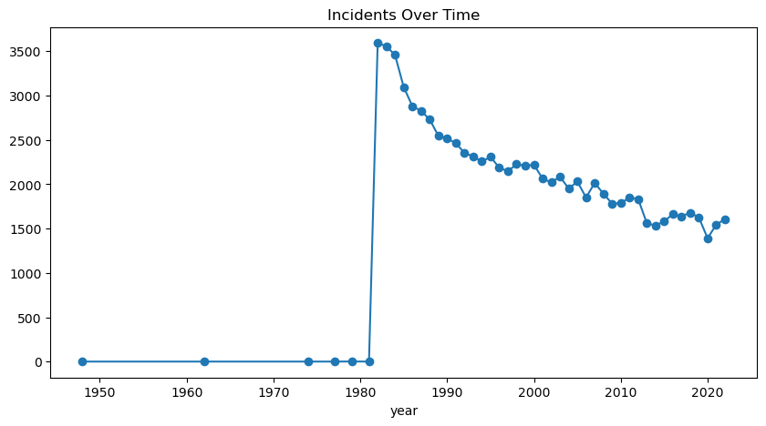

```python
incident_trend = df.groupby('year').size()

incident_trend.plot(kind='line', marker='o', figsize=(10, 5), title='Incidents Over Time')
```

## 2. Top Aircraft Models in Fatal Incidents

```python
df[df['injury.severity'] == 'fatal']
```

|  | event.id | investigation.type | accident.number | event.date | location | country | latitude | longitude | airport.code | airport.name | ... | air.carrier | total.fatal.injuries | total.serious.injuries | total.minor.injuries | total.uninjured | weather.condition | broad.phase.of.flight | report.status | publication.date | year |
| --- | --- | --- | --- | --- | --- | --- | --- | --- | --- | --- | --- | --- | --- | --- | --- | --- | --- | --- | --- | --- | --- |

0 rows × 32 columns

```python
df['injury.severity'].unique()
```

```
array(['Fatal(2)', 'Fatal(4)', 'Fatal(3)', 'Fatal(1)', 'Non-Fatal',
       'Incident', 'Fatal(8)', 'Fatal(78)', 'Fatal(7)', 'Fatal(6)',
       'Fatal(5)', 'Fatal(153)', 'Fatal(12)', 'Fatal(14)', 'Fatal(23)',
       'Fatal(10)', 'Fatal(11)', 'Fatal(9)', 'Fatal(17)', 'Fatal(13)',
       'Fatal(29)', 'Fatal(70)', 'Unavailable', 'Fatal(135)', 'Fatal(31)',
       'Fatal(256)', 'Fatal(25)', 'Fatal(82)', 'Fatal(156)', 'Fatal(28)',
       'Fatal(18)', 'Fatal(43)', 'Fatal(15)', 'Fatal(270)', 'Fatal(144)',
       'Fatal(174)', 'Fatal(111)', 'Fatal(131)', 'Fatal(20)', 'Fatal(73)',
       'Fatal(27)', 'Fatal(34)', 'Fatal(87)', 'Fatal(30)', 'Fatal(16)',
       'Fatal(47)', 'Fatal(56)', 'Fatal(37)', 'Fatal(132)', 'Fatal(68)',
       'Fatal(54)', 'Fatal(52)', 'Fatal(65)', 'Fatal(72)', 'Fatal(160)',
       'Fatal(189)', 'Fatal(123)', 'Fatal(33)', 'Fatal(110)',
       'Fatal(230)', 'Fatal(97)', 'Fatal(349)', 'Fatal(125)', 'Fatal(35)',
       'Fatal(228)', 'Fatal(75)', 'Fatal(104)', 'Fatal(229)', 'Fatal(80)',
       'Fatal(217)', 'Fatal(169)', 'Fatal(88)', 'Fatal(19)', 'Fatal(60)',
       'Fatal(113)', 'Fatal(143)', 'Fatal(83)', 'Fatal(24)', 'Fatal(44)',
       'Fatal(64)', 'Fatal(92)', 'Fatal(118)', 'Fatal(265)', 'Fatal(26)',
       'Fatal(138)', 'Fatal(206)', 'Fatal(71)', 'Fatal(21)', 'Fatal(46)',
       'Fatal(102)', 'Fatal(115)', 'Fatal(141)', 'Fatal(55)',
       'Fatal(121)', 'Fatal(45)', 'Fatal(145)', 'Fatal(117)',
       'Fatal(107)', 'Fatal(124)', 'Fatal(49)', 'Fatal(154)', 'Fatal(96)',
       'Fatal(114)', 'Fatal(199)', 'Fatal(89)', 'Fatal(57)', 'Fatal',
       'Substantial', 'Minor', 'Serious'], dtype=object)
```

```python
fatal_models = df[df['injury.severity'].str.lower() == 'fatal']['model'].value_counts().head(10)
```

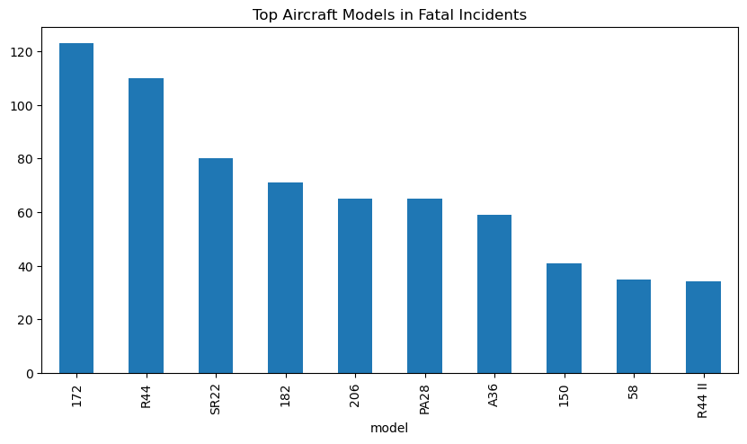

```python
if not fatal_models.empty:
    fatal_models.plot(kind='bar', figsize=(10, 5), title='Top Aircraft Models in Fatal Incidents')
else:
    print("No fatal incidents found in the dataset.")
```

## 3. Engine Type vs Severity

```python
pip install seaborn
```

```python
pip install plotly
```

[figure not shown]

```python
import seaborn as sns
import matplotlib.pyplot as plt
import plotly.express as px
import pandas as pd


df = pd.read_csv("c:/Users/User/dsc-phase-1-project-v3/data/aviation_data.csv")

plt.figure(figsize=(10, 5))
sns.countplot(data=df, x='Engine.Type', hue='Injury.Severity')
plt.title('Incident Severity by Engine Type')
plt.figure(figsize=(8, 4))  # Width = 8 inches, Height = 4 inches
```

```python
# Count incidents by country
country_counts = df['Country'].value_counts().reset_index()
country_counts.columns = ['Country', 'Incident_Count']
print(country_counts.head())
```

[output not shown]

[figure not shown]

```python
# Top 10 countries by incident count
top_countries = country_counts.head(10)

sns.barplot(data=top_countries, x='Incident_Count', y='Country')
```

## A relationship between aircraft Category and incident severity

```python
# Create aircraft type by combining Make and Model
df['Aircraft_Type'] = df['Make'] + " " + df['Model']
```

```python
# Count incidents by aircraft type and severity
type_severity_counts = df.groupby(['Aircraft.Category', 'Injury.Severity']).size().reset_index(name='Incident_Count')
```

```python
pivot_df = type_severity_counts.pivot(index='Aircraft.Category', columns='Injury.Severity', values='Incident_Count').fillna(0)

# focus on top 10 aircraft types by total incidents
top_types = pivot_df.sum(axis=1).sort_values(ascending=False).head(10).index
filtered_df = pivot_df.loc[top_types]
```

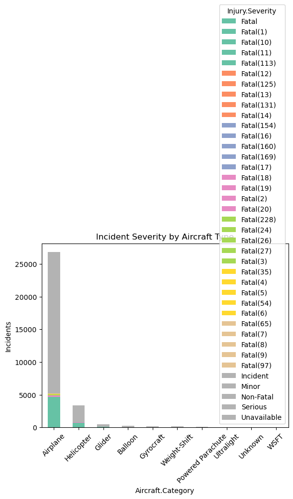

```python
filtered_df.plot.bar(stacked=True, colormap='Set2')
plt.title("Incident Severity by Aircraft Type")
plt.ylabel("Incidents")
plt.xticks(rotation=45)
plt.show()
```

### The correlation between weather patterns and incident severity

```python
# Groupby
weather_severity = aviation.groupby(['Weather.Condition', 'Injury.Severity']).size().reset_index(name='Incident_Count')

pivot_df = weather_severity.pivot(index='Weather.Condition', columns='Injury.Severity', values='Incident_Count').fillna(0)
```

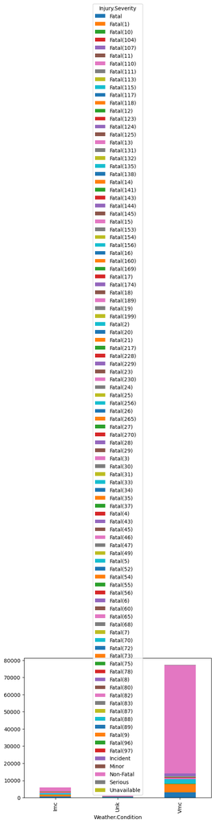

```python
pivot_df.plot(kind='bar', stacked=True)
plt.show()
```

### Aviation incidences in relation to amateur built aircrafts

```python
# Standardize the 'Amateur_Built' column for consistent analysis
aviation['Amateur.Built'] = aviation['Amateur.Built'].str.title().str.strip()
```

```python
# Incidence Counts
build_counts = aviation['Amateur.Built'].value_counts()
print(build_counts)
```

```
Amateur.Built
No     80312
Yes     8475
Name: count, dtype: int64
```

```python
# Group data by build type and injury severity, then count incidents
severity_by_build = aviation.groupby(['Amateur.Built', 'Injury.Severity']).size().unstack().fillna(0)
print(severity_by_build)
```

```
Injury.Severity   Fatal  Fatal(1)  Fatal(10)  Fatal(102)  Fatal(104)  \
Amateur.Built
No               4559.0    4945.0       31.0         2.0         1.0
Yes               703.0    1211.0        0.0         0.0         0.0

Injury.Severity  Fatal(107)  Fatal(11)  Fatal(110)  Fatal(111)  Fatal(113)  \
Amateur.Built
No                      1.0       10.0         1.0         1.0         2.0
Yes                     0.0        0.0         0.0         0.0         0.0

Injury.Severity  ...  Fatal(9)  Fatal(92)  Fatal(96)  Fatal(97)  Incident  \
Amateur.Built    ...
No               ...      18.0        2.0        1.0        2.0    2150.0
Yes              ...       0.0        0.0        0.0        0.0      25.0

Injury.Severity  Minor  Non-Fatal  Serious  Unavailable  Fatal(35)
Amateur.Built
No               196.0    61298.0    153.0         80.0        0.0
Yes               22.0     6044.0     20.0          6.0        1.0

[2 rows x 107 columns]
```

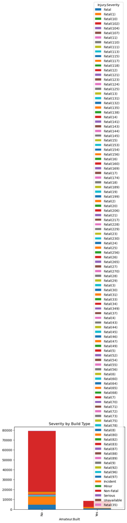

```python
# Create a stacked bar chart to visualize severity across build types
severity_by_build.plot(kind='bar', stacked=True)
plt.title("Severity by Build Type")
plt.show()
```

# Conclusion

## Aircraft Categories

### • Amateur-built aircraft have elevated risk profiles, often linked to mechanical failure or pilot error.

These insights can guide targeted safety audits, training programs, and engine modernization efforts.

# Recommendations

## Time-Based Safety Interventions

### • Increase seasonal safety campaigns during high-traffic period, targeting private and recreational pilots.

### • Use historical incident data to forecast risky periods and allocate inspection resources accordingly.

## Model-Specific Oversight

### • Conduct targeted audits and maintenance reviews for frequently involved models like the Cessna 172.

### • Encourage manufacturers to analyze incident data and improve design or training materials for high-risk models.

## Engine-Type Risk Mitigation

### • Mandate additional training for pilots operating single-engine aircraft, especially in adverse weather conditions.

### • Promote engine redundancy upgrades or enhanced emergency protocols for older single-engine fleets.

## Aircraft Category Focus

### • Require stricter certification and inspection for amateur-built and experimental aircraft.

### • Develop category-specific safety dashboards for regulators to monitor trends and intervene early.